# Practice Problem : Time Series Analysis

Akkash K N R

Congratulations on your new job! This time you are helping out Unicorn Investors with your data hacking skills. They are considering making an investment in a new form of transportation - JetRail. JetRail uses Jet propulsion technology to run rails and move people at a high speed! While JetRail has mastered the technology and they hold the patent for their product, the investment would only make sense, if they can get more than 1 Million monthly users with in next 18 months.

You need to help Unicorn ventures with the decision. They usually invest in B2C start-ups less than 4 years old looking for pre-series A funding. In order to help Unicorn Ventures in their decision, you need to forecast the traffic on JetRail for the next 7 months. You are provided with traffic data of JetRail since inception in the test file.

Evaluation Metric:

Root Mean Squre Error (RMSE) is the evaluation metric for this contest

Note: Public and private split is 20:80 where first 44 days in public and next 169 days in private

Link https://datahack.analyticsvidhya.com/contest/practice-problem-time-series-2/

### Load Library

```r
library(forecast)
library(xts)
library(h2o)
library(keras)
library(ggplot2)
library(quantmod)
library(zoo)
library(mxnet)
library(lubridate)
library(data.table)
library(caret)
library(xgboost)
```

### Load Dataset

```r
train <- read.csv('train.csv')
test <- read.csv('test.csv')
```

Lets explore the training Dataset

```r
summary(train)
str(train)
```

[output not shown]

Lets create a copy of the dataset

```r
ntrain <- train
ntest <- test
```

Convert the DateTime from string to datetime

```r
ntrain$Datetime <- as.POSIXct(ntrain$Datetime ,format="%d-%m-%Y %H:%M")
ntest$Datetime <- as.POSIXct(ntest$Datetime ,format="%d-%m-%Y %H:%M")
```

```r
ntrain$istrain <- 1; ntest$istrain <- 0; ntest$Count <- NA
```

Generally a Time Series consist of 3 components:- Seasonality,Trend and Irreducable(Random) Error

In the below plot we can clearly understand the trend and seasonality of the dataset

```r
ndata <- ts(ntrain[,3],frequency = 24)
decomp <- decompose(ndata,type="additive")
```

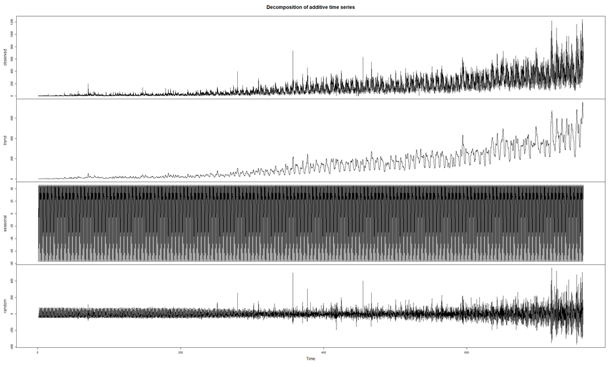

```r
plot(decomp)
```

### Time Series Models

#### Implementing Holt’s Winter Model

It is also know as three parameter smoothing technique. Level, Seasonality and Trend

$$\begin{aligned}
L_t &= \alpha(D_t/S_{t-s})+(1-\alpha)(L_{t-1}+T_{t-1}) \ &- (1) \\
T_{t} &= \beta(L_t-L_{t-1}) +(1-\beta)T_{t-1}\ &- (2) \\
S_{t} &= \gamma(D_t/L_{t}) +(1-\gamma)S_{t-s}\ &- (3) \\
F_{t+m} &= (L_t+mT_{t})*S_{t+m-s} \ &-(4) \\
\end{aligned}$$
Where L is Level, D is Preicted value, S is Seasonality, T is trend and m is the window size(how many periods ahead). Alpha, Beta and Gamma are coefficient parameters for Level, Trend and Seasonality.

We need to change the alpha, beta, gamma value to attain the best score.

```r
pred_Holt <- HoltWinters(ndata)
pred_Holt
```

```
Holt-Winters exponential smoothing with trend and additive seasonal component.

Call:
HoltWinters(x = ndata)

Smoothing parameters:
 alpha: 0.6430421
 beta : 0
 gamma: 0.1831402

Coefficients:
             [,1]
a    539.82305605
b      0.02467391
s1   -47.77036110
s2  -141.49805752
s3  -174.69802722
s4  -212.70957002
s5  -235.22836524
s6  -237.51079230
s7  -203.98874544
s8  -131.77006093
s9  -104.76378099
s10    8.45860311
s11  234.79143537
s12  258.59933582
s13  209.47058789
s14  113.10505561
s15  104.29778042
s16   85.12651551
s17   74.09525493
s18   76.72597316
s19   68.60025993
s20  153.16459862
s21   60.93463585
s22   22.20456437
s23    4.22765677
s24   24.90789047
```

```r
print(pred_Holt)
```

```
Holt-Winters exponential smoothing with trend and additive seasonal component.

Call:
HoltWinters(x = ndata)

Smoothing parameters:
 alpha: 0.6430421
 beta : 0
 gamma: 0.1831402

Coefficients:
             [,1]
a    539.82305605
b      0.02467391
s1   -47.77036110
s2  -141.49805752
s3  -174.69802722
s4  -212.70957002
s5  -235.22836524
s6  -237.51079230
s7  -203.98874544
s8  -131.77006093
s9  -104.76378099
s10    8.45860311
s11  234.79143537
s12  258.59933582
s13  209.47058789
s14  113.10505561
s15  104.29778042
s16   85.12651551
s17   74.09525493
s18   76.72597316
s19   68.60025993
s20  153.16459862
s21   60.93463585
s22   22.20456437
s23    4.22765677
s24   24.90789047
```

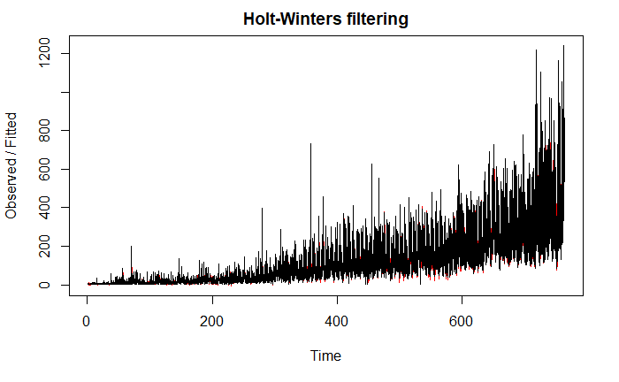

```r
plot(pred_Holt)
```

#### Implementing Forecast Exponential Smoothening

Exponential Smoothening is suitable for forecasting data with no trend or seasonal pattern.

$$\begin{aligned}
F_{t+1} &= \alpha*D_t+(1-\alpha)F_t \\
\end{aligned}$$
F(t+1) is the future forecast, alpha is coefficient parameter Dt is the output at time t, F(t) is the mean forecast. of time “t”

```r
#ets
pred_ets <- ets(ndata)
pred_ets
```

```
ETS(M,A,M)

Call:
 ets(y = ndata)

  Smoothing parameters:
    alpha = 0.3277
    beta  = 1e-04
    gamma = 0.0212

  Initial states:
    l = 3.7001
    b = 0.5586
    s=1.1423 1.2606 1.2524 1.2879 1.4304 1.1376
           1.1662 1.117 0.6517 1.3213 1.1199 1.441 1.1978 1.0684 1.0297 0.6819 0.4628 0.4284 0.5639 0.5185 0.5681 0.7024 1.1809 1.269

  sigma:  0.3396

     AIC     AICc      BIC
294486.2 294486.3 294712.9
```

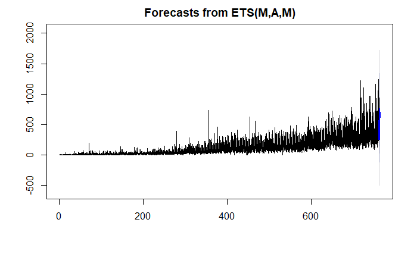

```r
plot(forecast(pred_ets))
```

#### Implementing Auto ARIMA

ARIMA is a “Auto Regression Integration with Moving Average”. ARIMA(p,d,q), where “p” is the order of auto regression, “q” is the order of moving average and “d” is first differencing involved.

```r
#ARIMA
pred_ar <- auto.arima(diff(ndata))
pred_ar
```

```
Series: diff(ndata)
ARIMA(4,0,0)(2,0,0)[24] with zero mean

Coefficients:
```

```
NaNs produced
```

```
          ar1      ar2      ar3      ar4    sar1    sar2
      -0.2244  -0.0982  -0.0711  -0.0127  0.3474  0.2728
s.e.   0.0088   0.0045   0.0079      NaN  0.0066  0.0053

sigma^2 estimated as 1320:  log likelihood=-91649.72
AIC=183313.4   AICc=183313.5   BIC=183368.1
```

#### Implementing STL

Also known as “Seasonal & Trend decomposition using Loess” is a type od decomposition, where Loess is a method for estimating nonlinear relationship.

```r
#STL
pred_STL <- stlm(ndata,modelfunction = ar ,s.window = 24)
```

Now lets predict the future…

```r
fcst_Holt <- forecast(pred_Holt,h=5112)
fcst_ets <- forecast(pred_ets,h=5112)
fcst_ar <- forecast(pred_ar,h=5112)
fcst_stl <- forecast(pred_STL,h=5112)
```

Plot the prediction

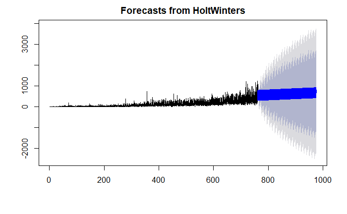

```r
plot(fcst_Holt)
```

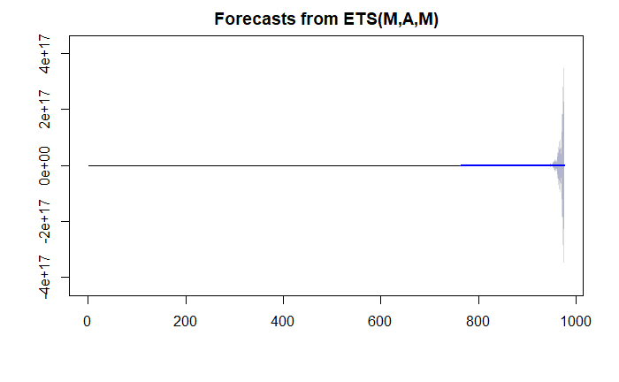

```r
plot(fcst_ets)
```

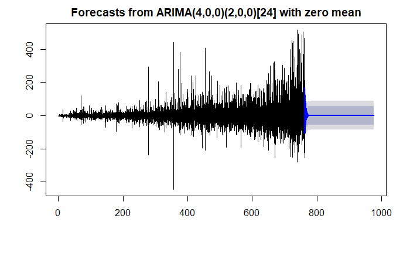

```r
plot(fcst_ar)
```

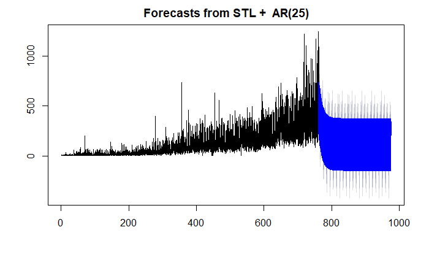

```r
plot(fcst_stl)
```

Now lets implement more advance models.

#### Implementing Neural Network,

Artificial Neural Network are used to find the nonlinear relationship.

http://neuralnetworksanddeeplearning.com/chap1.html

$$\begin{aligned}
N_j &= b_j+\sum_{j=1}^{n}w_{i,j}x_i \\
\end{aligned}$$

```r
nnet <- nnetar(diff(ndata))
```

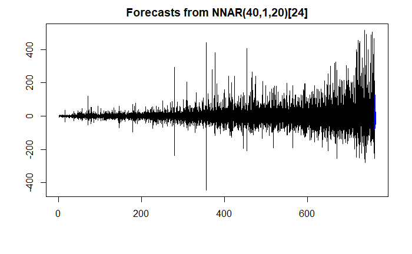

```r
plot(forecast(nnet))
```

```r
fcst_nnte <- forecast(nnet, h= 5112)
```

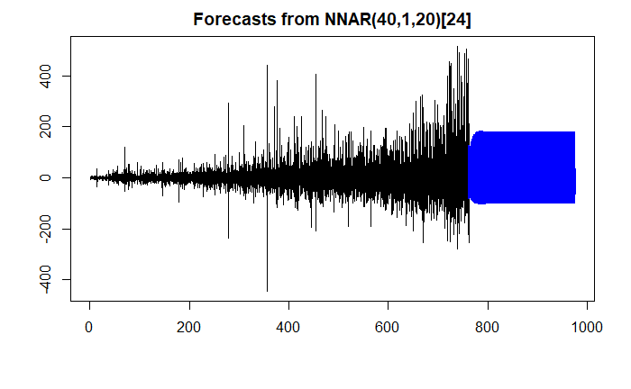

```r
plot(fcst_nnte)
```

```r
submission <- data.frame('ID'=test$ID,'Count'=fcst_Holt)
colnames(submission) <- c('ID','Count')
filename <- paste('ak_hw_',format(Sys.time(),"%Y%m%d%H%M%s"),sep = '_')
write.csv(submission,paste0(filename,'.csv',collapse = ''),row.names = FALSE)
```